# Économétrie — TD 3

Regressions MCO (EViews)

Pierre Beaucoral

# 1 Régression linéaire : rappel & pratique

## 1.1 Modèle de régression linéaire simple

Une régression consiste à expliquer les variations d’une variable dépendante $Y$ par celles d’une ou plusieurs variables indépendantes $X$.

On suppose la relation (droite de régression) :

$Y_i = \beta_0 + \beta_1 X_i + \varepsilon_i,\quad i=1,\dots,N$

où $\varepsilon_i$ est centré et non corrélé aux régressseurs.

**Objectif MCO (OLS).** Estimer $\beta_0,\beta_1$ en minimisant la somme des carrés :

$\min{\sum_{i=0}^N \varepsilon_i^2}= \min\sum_{i=0}^N \big(Y_i - \beta_0 - \beta_1 X_i\big)^2.$

**Tip**

$\beta_1$ Représente ici la magnitude de “l’effet” de la variable $X_1$ sur $Y$. $\varepsilon\_i$ Représente la partie non expliquée de la relation (ou terme d’erreur)

### 1.1.1 Terme d’erreur

L’introduction du terme d’erreur recouvre deux grands types d’erreurs :

▶ Erreur de spécication :

Les variables introduites ne sont pas susantes pour expliquer toutes les variations de Y

▶ Erreur de mesure :

La variable expliquée (Y) est mesurée de manière imparfaite (bruitée)

### 1.1.2 Prédiction de Y

Une fois estimée, la relation s’écrit:

$Y_i = \hat\beta\_0 + \hat\beta\_1 X_i +\hat\varepsilon_i$

Avec $\hat\varepsilon_i$, terme d’erreur estimé aussi appelé résidu, on peut prédire Y:

$\hat Y_i = \hat\beta_0 + \hat\beta_1 X_i$

### 1.1.3 Graphique 1 — Nuage de points + droite OLS

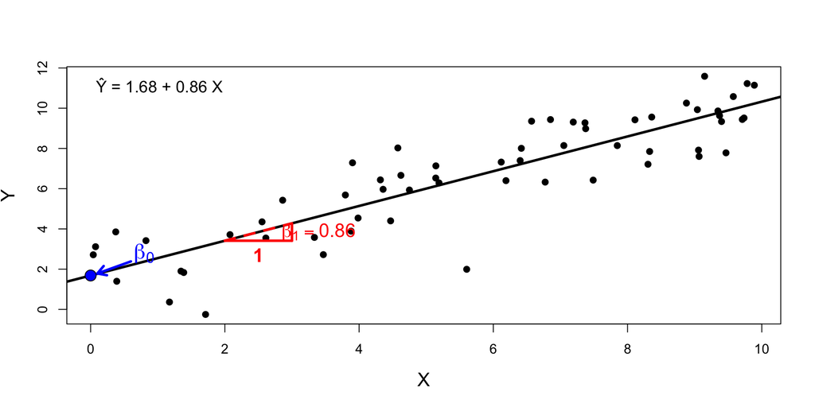

Figure 1: β₀ et β₁ illustrée par un triangle rectangle (Δx = 1, Δy = β₁ = 0.86).

```r
set.seed(42)
N  <- 60
x  <- sort(runif(N, 0, 10))
y  <- 2 + 0.8*x + rnorm(N, sd = 1.5)
df <- data.frame(x, y)
mod <- lm(y ~ x, data = df)

plot(df$x, df$y, pch = 19, xlab = "X", ylab = "Y", cex.lab = 1.4)
abline(mod, lwd = 3)

b0 <- coef(mod)[1]
b1 <- coef(mod)[2]

## ---- β0 : ordonnée à l'origine ----
points(0, b0, pch = 21, bg = "blue", cex = 1.8)
arrows(0.6, b0 + 0.7, 0.1, b0 + 0.1, length = 0.12,
       col = "blue", lwd = 3)
text(0.8, b0 + 1.1, expression(beta[0]),
     col = "blue", cex = 1.6, font = 2)

## ---- Triangle rectangle pour la pente ----
x0 <- 2                       # point de départ en X
y0 <- b0 + b1*x0               # point sur la droite

# Base de 1 en X et hauteur correspondante en Y = b1
x1 <- x0 + 1
y1 <- b0 + b1*x1

# Triangle
segments(x0, y0, x1, y0, col="red", lwd=3)  # base (Δx = 1)
segments(x1, y0, x1, y1, col="red", lwd=3)  # hauteur (Δy = β1)
segments(x0, y0, x1, y1, col="red", lwd=3, lty=2) # hypoténuse

# Étiquettes
text((x0+x1)/2, y0 - 0.7, "1", col="red", cex=1.4, font=2)             # Δx
text(x1 + 0.4, (y0 + y1)/2,
     bquote(beta[1] == .(round(b1,2))),
     col="red", cex=1.4, font=2)                                       # Δy = β1

legend("topleft",
       legend = sprintf("Ŷ = %.2f + %.2f X", b0, b1),
       bty = "n", cex = 1.2)
```

## 1.2 Forme matricielle (régression multiple)

En multiple :$Y = X\beta + \varepsilon,\qquad \hat\beta = (X'X)^{-1}X'Y.$

### 1.2.1 Exemple avec deux régresseurs

```r
set.seed(123)
N  <- 120
x1 <- runif(N, 0, 10)
x2 <- rnorm(N, 5, 2)
y  <- 1.5 + 0.6*x1 - 0.3*x2 + rnorm(N, sd = 1)
d <- data.frame(y, x1, x2)
m <- lm(y ~ x1 + x2, data = d)
summary(m)
```

```
Call:
lm(formula = y ~ x1 + x2, data = d)

Residuals:
     Min       1Q   Median       3Q      Max
-1.78604 -0.62855 -0.05144  0.66068  2.06691

Coefficients:
            Estimate Std. Error t value Pr(>|t|)
(Intercept)  1.87289    0.26031   7.195 6.43e-11 ***
x1           0.61541    0.03088  19.931  < 2e-16 ***
x2          -0.37545    0.04565  -8.224 3.07e-13 ***
---
Signif. codes:  0 '***' 0.001 '**' 0.01 '*' 0.05 '.' 0.1 ' ' 1

Residual standard error: 0.9416 on 117 degrees of freedom
Multiple R-squared:  0.7792,    Adjusted R-squared:  0.7755
F-statistic: 206.5 on 2 and 117 DF,  p-value: < 2.2e-16
```

**Note**

Ceci est un exemple de tableau de régression, sur Eviews, le tableau sera similaire, mais un peu différent, celui-là a été fait dans R pour l’exemple.

# 2 Procédure sur EViews

## 2.1 Estimation

- Faire Object →New Object →Equation
- Autre méthode :
  - 1. Sélectionner les variables en débutant par la variable dépendante (Y)
  - 2. Faire Open →as Equation
- La fenêtre ouverte a deux onglets :

  ▶ Specification : Entrer la spécification choisie

  ▶ Options :
  - Cet onglet sert pour la correction de la matrice de variance-covariance
  - Nous ignorons pour le moment cet onglet

## 2.2 Estimation

- Equation specification : Permet d’entrer l’équation estimée

  ▶ Il faut mettre d’abord la variable expliquée (Y) puis les variables explicatives (X1 ; X2, . . .) : `Y X1 X2 ... c`

  ▶ `c` sert à spécier l’introduction d’une constante

  ▶ Nota : Si la deuxième méthode est utilisée, l’équation est déjà spéciée mais peut être modiée
- Estimation Settings :

  ▶ Method : Permet de choisir l’estimateur (MCO [LS] par défaut)

  ▶ Sample : Permet de choisir l’échantillon retenu

## 2.3 Commandes post-estimations

- Les coeficients estimés sont conservés dans l’objet `c`
- Les résidus estimés de la dernière équation sont stockés dans”resid”
- Name :
  - Permet de conserver la régression dans un workfile
- View →representation :
  - Permet de visualiser la ligne de commande eectuée, l’équation théorique et l’équation avec les valeurs estimées des coeficients
- View →estimation output :
  - Permet de visualiser les résultats bruts de la régression.

## 2.4 Commandes post-estimations

- View →actual, fitted, residual :

  ▶ actual : valeur de la variable dépendante utilisée dans la régression,

  ▶ fitted : valeurs de la variable dépendante prédites par la régression en appliquant les coeficients de la régression sur les variables explicatives,

  ▶ residual (actual-tted) : indication sur les erreurs de prévisionéventuelles, bornes à 5%.
- Freeze :

Permet de conserver les résultats.

## 2.5 Commandes post-estimations

- Il est possible de vouloir conserver plusieurs éléments de l’équation estimée

  ▶ Ex : Pour calculer des points de retournement ou pour certains tests il faut conserver les R2, la SCR, . . .
- Pour ce faire, il sut généralement de créer un objet (scalaire, matrice) qui puisse accueillir ces nouveaux éléments

  ▶ Exemples :
  - Scalaire : `scalar nom=nomequation.operation`
  - Matrice : `matrix nom=nomequation.operation`
  - `Ex : scalar rsq=eq1.@r2`
  - `Ex : matrix coefficients=eq1.@coefs`

**Tip**

L’opération commence par .@ en général

## 2.6 Commandes post-estimations

Quelques éléments disponibles (non exhaustif):

| Élément | Opération | Type d’objet |
| --- | --- | --- |
| R² | `@r2` | `scalar` |
| R² ajusté | `@rbar2` | `scalar` |
| SCR | `@ssr` | `scalar` |
| Coefficient pour la *i*-ème variable | `c(i)` | `scalar` |
| t-stat pour la *i*-ème variable | `@tstats(i)` | `scalar` |
| Matrice de variance-covariance | `@coefcov` | `matrix` |
| Matrice des coefficients | `@coefs` | `matrix` |
| Matrice des t-stat | `@tstats` | `matrix` |

> Une liste plus complète est disponible dans Users Guide II page 16

## 2.7 Le coeficient de détermination : Le $R^2$

- Le pouvoir explicatif du modèle

  ▶ L’économétrie cherche à expliquer les variations de Y. Ceci est la variabilité totale (SCT pour somme des carrés totale) et est donnée par : $SCT=\sum_{i=1}^N(y_i - \bar y)^2= SCE + SCR$

  ▶ Cette variabilité se décompose en :
  - Variabilité expliquée : SCE (pour somme des carrés expliquée)
  - Variabilité non expliquée : SCR (pour somme des carrés des résidus)

## 2.8 Le coefficient de détermination : le $R^2$

- Le coefficient de détermination mesure le pouvoir explicatif du modèle et se calcule comme suit :

$R^2 = \frac{SCE}{SCT} = 1 - \frac{SCR}{SCT} \quad\text{avec}\quad \begin{cases} \displaystyle SCR = \sum_{i=1}^N \hat{\varepsilon}_i^2 \\ \displaystyle SCT = \sum_{i=1}^N (y_i - \bar{y})^2 \end{cases}$

- Ce coefficient mesure la qualité de l’ajustement de la régression en indiquant le pourcentage de la variance totale expliquée par le modèle :
  - Si ( $R^2 \to 1$ ) : le modèle est **très explicatif**.
  - Si ( $R^2 \to 0$ ) : le modèle est **peu explicatif**.

## 2.9 Le coefficient de détermination : le $R^2$

- Il faut en réalité faire attention avec le ( $R^2$ ) :
  - Le ( $R^2$ ) augmente mécaniquement avec l’ajout de variables explicatives.
  - Il faut par conséquent privilégier une version ajustée du nombre de degrés de liberté, le ( $R^2$ ) ajusté :

$\bar{R}^2 = 1 - (1 - R^2)\frac{N-1}{N-p}$

# 3 Significativité statistique

## 3.1 La significativité simple

- **Objectif :** déterminer si le coefficient estimé est précis.
- Pour cela, on fait un **test de Student** à partir de :
  - la valeur estimée du coefficient ( $\hat{\beta}_j$ ),
  - et la valeur estimée de son écart-type ( $\hat{\sigma}_{\beta}$ ).

    *Rappel : l’écart-type mesure la dispersion d’une série autour de sa moyenne.*
- La statistique de test est la suivante :

$t_{\beta_j} = \frac{\hat{\beta}_j - \beta_{\text{th}}}{\hat{\sigma}_{\beta}}$

- Les hypothèses testées sont :
  - $H_0 : \beta_j = \beta{\text{th}}$
  - $H_1 : \beta_j \neq \beta{\text{th}}$

## 3.2 La significativité simple

- Le test consiste souvent à savoir si le paramètre est significativement différent de 0 ( $\beta_{\text{th}} = 0$ ).
- La statistique de test devient donc :

$t_{\beta_j} = \frac{\hat{\beta}_j}{\hat{\sigma}_{\beta}}$

- Les hypothèses testées deviennent :
  - $H_0 : \beta_j = 0$
  - $H_1 : \beta_j \neq 0$

## 3.3 La significativité simple

- La statistique de test calculée $t_{\beta_j}$ *est comparée à la statistique théorique* $t\alpha$ tabulée pour un risque de première espèce $\alpha$.
- Remarque : il s’agit en général d’un **test bilatéral**.

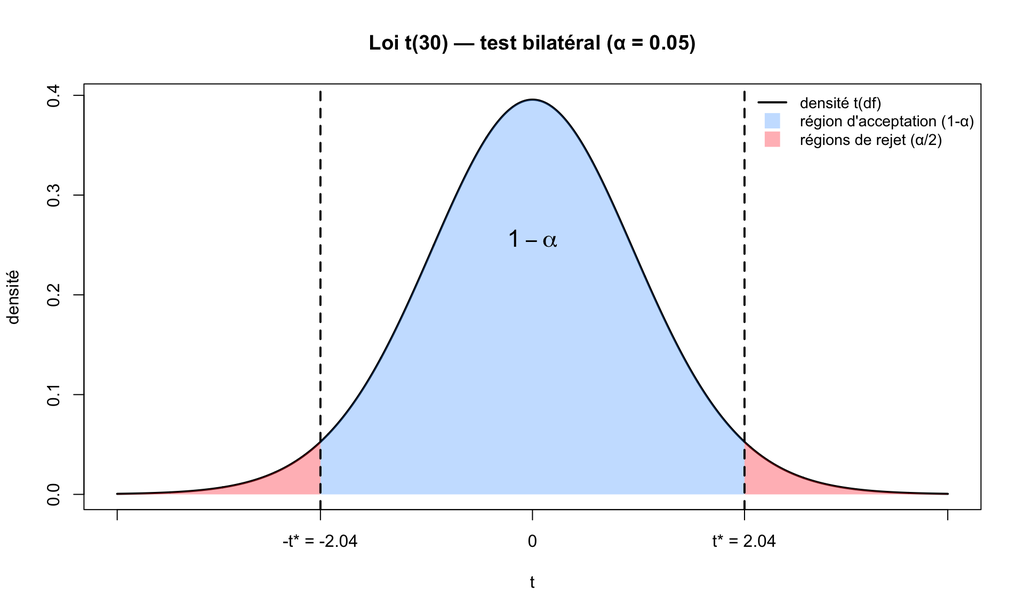

```r
alpha <- 0.05
df    <- 30
xlim  <- c(-4, 4)
tcrit <- qt(1 - alpha/2, df = df)

xx <- seq(xlim[1], xlim[2], length.out = 2000)
yy <- dt(xx, df = df)

plot(xx, yy, type = "l", lwd = 2,
     xlab = "t", ylab = "densité",
     main = sprintf("Loi t(%d) — test bilatéral (α = %.2f)", df, alpha),
     xaxt = "n")  # on dessine l'axe X nous-mêmes

shade_region <- function(x_from, x_to, col){
  xseq <- seq(x_from, x_to, length.out = 500)
  yseq <- dt(xseq, df = df)
  polygon(c(xseq, rev(xseq)), c(yseq, rep(0, length(yseq))),
          col = col, border = NA)
}

# Colorier les zones
shade_region(-tcrit, tcrit, col = rgb(0.2, 0.6, 1, 0.3))      # zone centrale
shade_region(xlim[1], -tcrit, col = rgb(1, 0.2, 0.2, 0.35))   # queue gauche
shade_region(tcrit, xlim[2],  col = rgb(1, 0.2, 0.2, 0.35))   # queue droite

# Traits verticaux
abline(v = c(-tcrit, tcrit), lwd = 2, lty = 2)

# Axe X avec -t* et t* comme graduations
axis(1,
     at = c(xlim[1], -tcrit, 0, tcrit, xlim[2]),
     labels = c("", sprintf("-t* = %.2f", -tcrit), "0", sprintf("t* = %.2f", tcrit), ""),
     tick = TRUE)

# Étiquettes
text(0, max(yy)*0.65, expression(1 - alpha), cex = 1.4)
# α/2 décalés sous l'axe X, vers l'extérieur
text(-tcrit, -0.015, expression(alpha/2), cex = 1.2, pos = 1, offset = 1)
text( tcrit, -0.015, expression(alpha/2), cex = 1.2, pos = 1, offset = 1)

legend("topright",
       legend = c("densité t(df)",
                  "région d'acceptation (1-α)",
                  "régions de rejet (α/2)"),
       lty = c(1, NA, NA), lwd = c(2, NA, NA),
       pch = c(NA, 15, 15),
       pt.cex = 2,
       col = c("black", rgb(0.2,0.6,1,0.3), rgb(1,0.2,0.2,0.35)),
       bty = "n", cex = 0.9)
```

## 3.4 La significativité simple — procédure

1. **Calculer** la statistique de Student (Coef / SE) : $t_{\beta_j} = \hat{\beta}j / {\sigma}{\hat\beta}$.
2. **Choisir** un niveau de risque de première espèce $\alpha$.
3. **Déterminer** la valeur critique tabulée $t_{\alpha/2, \nu}$ pour un **test bilatéral**, avec $\nu = N - p \quad (\text{ddl : nb d'observations } N \text{ moins nb de paramètres } p)$ .
4. **Conclure** sur la significativité selon la règle de décision :
   - si $|t| < t_{\alpha/2, \nu}) (\Rightarrow) \text{ non-rejet de }H_0$
   - si $|t| \ge t_{\alpha/2, \nu}) (\Rightarrow)\text{ rejet de }(H_0)$

### 3.4.1 **Tableau de décision test bilatéral**

| Décision / Réalité | $H_0$ vraie | $H_0$ fausse |
| --- | --- | --- |
| **Rejeter** $H_0$ | **Erreur** $\alpha$ | **Décision correcte** |
| **Ne pas rejeter** $H_0$ | **Décision correcte** | **Erreur** $\beta$ |

**Caution**

On parle de rejet ou non rejet d’une hypothèse, pas d’acceptation.

## 3.5 La significativité conjointe

**Tip**

Dans un modèle, nous pouvons nous intéresser à déterminer si nos différentes variables ont un effet significatif sur notre variable $Y$, dépendemment les unes des autres. C’est à dire, est-ce que mes variables sont significatives *conjointement* ( $X_1$ significative ET $X_N$ …)

Dans ce cadre, les simples tests de Student ne sont pas suffisants, pour tester plusieurs restrictions, il faut recourir à d’autres tests:

▶ Test de Fisher dans le cas des modèles linéaires

▶ Tests de Wald, du log de vraisemblance ou du multiplicateurs de Lagrange dans les cas plus complexes

## 3.6 La significativité conjointe le test de Fisher (F-test)

- Le **F-test** permet de tester la significativité conjointe de plusieurs paramètres, voire la significativité globale d’un modèle linéaire. La statistique de test est la suivante :

$F = \displaystyle\frac{SCR_r - SCR_{nr}}{SCR_{nr}}{\displaystyle \frac{N - p}{q}}$

où :

- $q$ : nombre de restrictions testées (sans la constante),
- $p$ : nombre de paramètres dans le modèle non restreint (avec la constante),
- $N$ : nombre d’observations.
- $SCR_r$ : somme des carrés des résidus du modèle **restreint** (les paramètres imposés sont fixés),
- $SCR_{nr}$ : somme des carrés des résidus du modèle **non restreint** (modèle usuel non contraint).

## 3.7 La significativité conjointe — F-test (unilatéral)

- Le test de Fisher est **unilatéral** (rejet dans la **queue droite**).
- Sous (H_0), la statistique suit une loi de **Fisher–Snedecor** : $F \sim F(q, N-p)$ , où $q$ = nb de restrictions testées et $N-p$ = ddl résiduels du modèle non restreint.
- Les logiciels (EViews, R, etc.) donnent directement (F), la p-value et la table ANOVA.

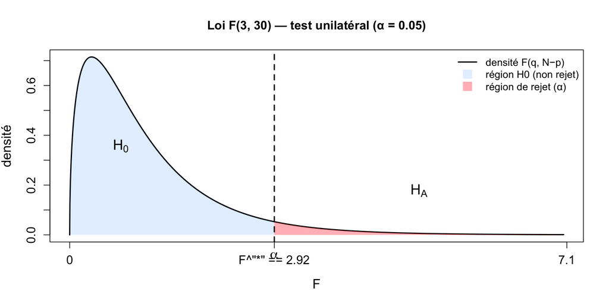

```r
alpha <- 0.05
q     <- 3
df2   <- 30
Fcrit <- qf(1 - alpha, df1 = q, df2 = df2)

xmax <- qf(0.999, df1 = q, df2 = df2)
xx   <- seq(0, xmax, length.out = 2000)
yy   <- df(xx, df1 = q, df2 = df2)

plot(xx, yy, type = "l", lwd = 2,
     xlab = "F", ylab = "densité",
     main = sprintf("Loi F(%d, %d) — test unilatéral (α = %.02f)", q, df2, alpha),
     cex.lab = 1.3, cex.axis = 1.2, xaxt = "n")

shade_region <- function(x_from, col){
  xseq <- seq(x_from, xmax, length.out = 600)
  yseq <- df(xseq, df1 = q, df2 = df2)
  polygon(c(xseq, rev(xseq)), c(yseq, rep(0, length(yseq))),
          col = col, border = NA)
}

# Zones
polygon(c(0, xx[xx <= Fcrit], Fcrit),
        c(0, yy[xx <= Fcrit], 0),
        col = rgb(0.2, 0.6, 1, 0.15), border = NA)
shade_region(Fcrit, col = rgb(1, 0.2, 0.2, 0.35))

abline(v = Fcrit, lwd = 2, lty = 2)

# Axe X plus lisible avec F* bien marqué
axis(1,
     at = c(0, Fcrit, round(xmax,1)),
     labels = c("0",
                bquote(F^"*" == .(round(Fcrit,2))),
                round(xmax,1)),
     cex.axis = 1.2)

# Étiquettes
text(mean(c(0,Fcrit))*0.5, max(yy)*0.5, expression(H[0]), cex = 1.4)
text((Fcrit + xmax)/2, max(yy)*0.25, expression(H[A]), cex = 1.4)
text(Fcrit, par("usr")[3] - 0.02, expression(alpha),
     xpd = NA, pos = 1, cex = 1.3)

legend("topright",
       legend = c("densité F(q, N−p)",
                  "région H0 (non rejet)",
                  "région de rejet (α)"),
       lty = c(1, NA, NA), lwd = c(2, NA, NA),
       pch = c(NA, 15, 15), pt.cex = 2,
       col = c("black", rgb(0.2,0.6,1,0.15), rgb(1,0.2,0.2,0.35)),
       bty = "n", cex = 1)
```

## 3.8 La significativité conjointe — hypothèses usuelles du F-test

- On teste généralement la contrainte selon laquelle **tous les coefficients (hors constante) sont nuls**.
  - $H_0$ : tous les coefficients du modèle sont égaux à 0 (sauf l’intercept), c.-à-d. $H_0$ : $\beta_1=\beta_2=\cdots=\beta_p=0$
  - $H_1$ : **au moins un** coefficient est différent de 0.
- Dans ce cas, le **modèle contraint** est le modèle **avec seule la constante**. **Règle de décision :**  
  si $F > F_{\text{table}}$ (au niveau $\alpha)$et ddl $(q, N-p)$) $\Rightarrow$ **rejet de** $H_0$.
- **Interprétation :**
  - **Non-rejet de** $H_0$ $\Rightarrow$ pas de relation linéaire significative entre la variable expliquée et l’ensemble des variables explicatives.
  - Autrement dit, la **SCE** (somme des carrés expliquée) n’est pas significativement différente de 0 ; la variabilité de (Y) demeure essentiellement **aléatoire**.

## 3.9 La significativité conjointe — F-Test : procédure EViews

- **Procédure à suivre :**
  1. Régresser le modèle **non contraint** et relever la SCR.
  2. Régresser le modèle **contraint** et relever la SCR.
  3. Calculer la statistique de Fisher.
  4. Comparer la valeur obtenue à la valeur théorique (table de Fisher).

## 3.10 La significativité conjointe — F-Test : Exemple de commandes EViews

`equation eqnr Y X1 X2 X3 X4 X5 c`

`scalar scrnr = eqnr.@ssr`

`equation eqr Y X1 X3 c`

`scalar scrr = eqr.@ssr`

Ici :

## 3.11 La significativité conjointe — Wald-test

- La procédure selon le **Wald-test** est pré-enregistrée dans EViews :
  1. **Ouvrir** les résultats de l’estimation.
  2. **Menu :** `View → Coefficient diagnostic → Wald test`.
  3. **Saisir les contraintes** de la forme :

     ```
     c(numéro_coef1) = 0
     c(numéro_coef2) = 0
     ```

     par exemple :

     ```
     c(3) = 0
     c(5) = 0
     ```

# 4 Significativité économique

**Important**

Une variable peut avoir une très grande significativité statistique mais une faible significativité économique. Ici nous ne nous intéréssons pas à la “robustesse” de l’estimation de l’effet, mais à sa “magnitude”

L’interprétation du coefficient estimé $\beta$ dépend de la manière dont **Y** (variable expliquée) et **X** (variable explicative) sont exprimées : en **niveau** ou en **logarithme**.

## 4.1 Significativité économique - un tableau récapitulatif :

| Variable expliquée (Y) | Variable explicative (X) | Interprétation du coefficient $\beta$ |
| --- | --- | --- |
| **Niveau** | **Niveau** | Une augmentation de **1 unité** de X entraîne une variation moyenne de $\beta$ unités de Y. |
| **Niveau** | **Logarithme** | Une augmentation de **1 %** de X entraîne une variation moyenne de $\beta / 100$ unités de Y. |
| **Logarithme** | **Niveau** | Une augmentation de **1 unité** de X entraîne une variation moyenne de $\beta \times 100$ % de Y. |
| **Logarithme** | **Logarithme** | Une augmentation de **1 %** de X entraîne une variation moyenne de $\beta$ % de Y. |

## 4.2 Questions – Réponses TD3 (Module 3)

### 4.2.1 Question : Importez la base de données sur les compagnies aériennes.

**Afficher la réponse**

Menu **File → Open → Foreign Data as Workfile** puis sélectionner le fichier de données.

### 4.2.2 Question : Créez le logarithme du nombre de passagers. Quelle est l’utilité de cette transformation ?

**Afficher la réponse**

Commande : `genr logpassagers = log(passagers)`

Cette transformation :

- réduit l’impact des valeurs extrêmes en **compressant l’échelle**,
- rapproche la distribution d’une **loi normale**,
- **stabilise les variances**,
- permet une **interprétation en pourcentage** : une variation d’une unité du log ≈ une variation d’environ 100 % de la variable d’origine,
- aide à **linéariser les relations** et donc facilite l’usage de la régression linéaire.

**Afficher la réponse**

Menu **Object → New Object → Equation**, choisir « Linear ».  
Même si la variable dépendante est en logarithme, l’équation reste **linéaire** car les variables explicatives apparaissent en **première puissance** et la relation est **additive**.

### 4.2.4 Question : Distinguez les variables dépendantes, indépendantes, d’intérêt et de contrôle.

**Afficher la réponse**

- **Variable dépendante (expliquée)** : `logpass` (log du nombre de passagers).
- **Variables explicatives** : `Ratio`, croissance annuelle du trafic aérien de la destination principale (2010-2013), `public`, `low cost`, `age`, `intercontinental`, croissance annuelle du trafic aérien du pays d’origine (2010-2013).
- **Variable d’intérêt** : `Ratio`.
- **Variables de contrôle** : toutes les autres variables explicatives listées ci-dessus.

### 4.2.5 Question : D’après le R² de l’estimation, l’équation a-t-elle un pouvoir explicatif correct ?

**Afficher la réponse**

Le R² obtenu est ≈ 0,39 : le modèle explique environ **40 % de la variabilité** du nombre de passagers.  
⇒ **pouvoir explicatif modéré**, le modèle reste relativement peu explicatif.

### 4.2.6 Question : Le nombre d’accidents par passagers est-il significativement différent de zéro ?

**Afficher la réponse**

Test de Student bilatéral :

### 4.2.7 Question : Distinguer entre accidents mortels et non mortels et réestimer l’équation.

**Afficher la réponse**

Créer les variables :

`genr Dummy_fatal = fatal>=1` `genr Dummy_non_fatal = non_fatal>=1`

Puis relancer la régression en remplaçant `ratio` par les deux nouvelles variables.

### 4.2.9 Question : Quelle variable semble la plus importante d’un point de vue économique ? Comment interpréter le coefficient obtenu ?

**Afficher la réponse**

**Procédure :**

Dans EViews → `View → Coefficient diagnostics → Scaled coefficient`.

Le **coefficient standardisé** indique de combien d’écarts-types Y varie quand X varie d’un écart-type.

Cela permet de comparer directement l’importance relative des variables.

**Résultat :**

La variable **intercontinentale** a le plus grand coefficient standardisé (~0,42).

Comme Y est en logarithme et X en niveau, cela signifie qu’une compagnie qui devient **intercontinentale** augmente en moyenne le nombre de passagers d’environ **10 %**, toutes choses égales par ailleurs.

⇒ C’est la variable la plus importante d’un point de vue économique.